# Preclustering data checks

Author

Alexander Lawless

Published

13-02-2025

**expand for setup code chunk**

```r
knitr::opts_chunk$set(echo = FALSE, warning=FALSE, message=FALSE, fig.width =12, fig.height = 9)

library(tidyverse)
library(janitor)

key_measures <-
  read_csv("CSDS_Cluster_analysis___key_measures.csv") |>
  clean_names() |>
  mutate(
    team_input_count = as.numeric(team_input_count),
    intermittent_care_periods = as.numeric(intermittent_care_periods),
    avg_contact_duration = as.numeric(avg_contact_duration),
    acute_admissions_2223 = as.numeric(acute_admissions_2223)
  )


# Remove date fields and replace NA's where appropriate
key_measures_reduced <-
  key_measures |>
  select(-c(first_contact, last_contact, care_mid_date)) |>
  mutate(
    intermittent_care_periods = replace_na(intermittent_care_periods, 0),
    acute_admissions_2223 = replace_na(acute_admissions_2223, 0)
    ) |> #2,120,821
  anti_join(
    key_measures |>
      group_by(person_id) |>
      mutate(rn = row_number()) |> # remove any duplicate person_id rows - just in case
      filter(rn > 1),
    by = "person_id"
    ) # 2,120,817


# Clean names for graphs
key_measure_lookup <-
  tribble(
    ~variable, ~variable_clean,
    "person_id"                 , "0. Person ID",
    "care_contacts"             , "A. Care contacts",
    "referrals"                 , "B. Referrals",
    "length_care"               , "C. Care length",
    "average_daily_contacts"    , "D. Average daily contacts",
    "contact_prop_aft_midpoint" , "E. Contact proportion after midpoint",
    "team_input_count"          , "F. Team input count",
    "intermittent_care_periods" , "G. Intermittent care periods",
    "specialist_contact_prop"   , "H. Specialist care proportion",
    "remote_contact_prop"       , "I. Remote care proportion",
    "avg_contact_duration"      , "J. Average contact duration",
    "acute_admissions_2223"     , "K. Acute admission count"
  )

# Read in imputed key measures

key_measures_reduced_imp <- read_csv("key_measures_reduced_imp.csv")
```

# Pre-cluster checks

## Data summary

```r
skimr::skim(key_measures_reduced)
```

Data summary

| Name | key_measures_reduced |
| --- | --- |
| Number of rows | 2120785 |
| Number of columns | 13 |
| _______________________ |  |
| Column type frequency: |  |
| character | 2 |
| numeric | 11 |
| ________________________ |  |
| Group variables | None |

**Variable type: character**

| skim_variable | n_missing | complete_rate | min | max | empty | n_unique | whitespace |
| --- | --- | --- | --- | --- | --- | --- | --- |
| person_id | 0 | 1 | 15 | 15 | 0 | 2120785 | 0 |
| org_id_provider | 0 | 1 | 3 | 5 | 0 | 193 | 0 |

**Variable type: numeric**

| skim_variable | n_missing | complete_rate | mean | sd | p0 | p25 | p50 | p75 | p100 | hist |
| --- | --- | --- | --- | --- | --- | --- | --- | --- | --- | --- |
| care_contacts | 0 | 1.00 | 12.60 | 39.77 | 2.00 | 2 | 4.0 | 9.0 | 2443 | ▇▁▁▁▁ |
| referrals | 0 | 1.00 | 2.33 | 2.59 | 1.00 | 1 | 2.0 | 3.0 | 363 | ▇▁▁▁▁ |
| length_care | 0 | 1.00 | 142.00 | 111.43 | 0.00 | 42 | 114.0 | 237.0 | 364 | ▇▅▃▃▃ |
| average_daily_contacts | 0 | 1.00 | 1.06 | 0.29 | 1.00 | 1 | 1.0 | 1.0 | 16 | ▇▁▁▁▁ |
| contact_prop_aft_midpoint | 0 | 1.00 | 51.06 | 18.52 | 0.22 | 40 | 50.0 | 62.5 | 100 | ▁▅▇▃▁ |
| team_input_count | 963397 | 0.55 | 1.59 | 1.01 | 1.00 | 1 | 1.0 | 2.0 | 14 | ▇▁▁▁▁ |
| intermittent_care_periods | 0 | 1.00 | 2.12 | 1.95 | 0.00 | 1 | 2.0 | 3.0 | 17 | ▇▂▁▁▁ |
| specialist_contact_prop | 0 | 1.00 | 87.43 | 29.74 | 0.00 | 100 | 100.0 | 100.0 | 100 | ▁▁▁▁▇ |
| remote_contact_prop | 0 | 1.00 | 25.61 | 31.51 | 0.00 | 0 | 10.6 | 50.0 | 100 | ▇▂▂▁▁ |
| avg_contact_duration | 26155 | 0.99 | 29.66 | 26.96 | 0.00 | 20 | 30.0 | 35.0 | 9726 | ▇▁▁▁▁ |
| acute_admissions_2223 | 0 | 1.00 | 0.64 | 1.94 | 0.00 | 0 | 0.0 | 1.0 | 162 | ▇▁▁▁▁ |

## 1. Check for Missing Values

```r
sum(is.na(key_measures_reduced))
```

```
[1] 989552
```

Impute values for `team_input_count` and `avg_contact_duration`.

```r
# Calculate the probability distribution
## Team input
prob_distribution_team <-
  key_measures_reduced |>
  group_by(org_id_provider, team_input_count) |>
  summarise(n = n()) |>
  filter(!is.na(team_input_count)) |>
  mutate(probability = n / sum(n),
         team_count = max(team_input_count)) |>
  rename(field = team_input_count)

## Overall probability distribution for team input (ungrouped by org_id)
overall_prob_distribution_team <-
  key_measures_reduced |>
  group_by(team_input_count) |>
  summarise(n = n()) |>
  filter(!is.na(team_input_count)) |>
  mutate(probability = n / sum(n)) |>
  rename(field = team_input_count)

## Avg contact duration
prob_distribution_duration <-
  key_measures_reduced |>
  group_by(avg_contact_duration) |>
  summarise(n = n()) |>
  filter(!is.na(avg_contact_duration)) |>
  mutate(probability = n / sum(n)) |>
  rename(field = 1)

# Function to impute missing values for avg_contact_duration
impute_avg_contact_duration <- function(series, distribution_df) {
  na_indices <- which(is.na(series))
  sampled_values <- sample(distribution_df$field, size = length(na_indices), replace = TRUE, prob = distribution_df$probability)
  series[na_indices] <- sampled_values
  return(series)
}

# Function to impute missing values for team_input_count
impute_team_input_count <- function(series, distribution_df, overall_distribution_df, org_id_provider) {
  na_indices <- which(is.na(series))
  sampled_values <- vector("numeric", length(na_indices))

  for (i in seq_along(na_indices)) {
    org_id <- org_id_provider[na_indices[i]]
    subset_df <- distribution_df[distribution_df$org_id_provider == org_id, ]

    sampled_values[i] <- if (nrow(subset_df) > 1) {
      sample(subset_df$field, size = 1, replace = TRUE, prob = subset_df$probability)
    } else if (nrow(subset_df) == 1) {
      subset_df$field
    } else {
      sample(overall_distribution_df$field, size = 1, replace = TRUE, prob = overall_distribution_df$probability)
    }
  }

  series[na_indices] <- sampled_values
  return(series)
}

# Impute NA values
key_measures_reduced_imp <-
  key_measures_reduced |>
  mutate(
    team_input_count = impute_team_input_count(team_input_count, prob_distribution_team, overall_prob_distribution_team, org_id_provider),
    avg_contact_duration = impute_avg_contact_duration(avg_contact_duration, prob_distribution_duration)
  )
```

Test imputed data for NA’s:

```r
sum(is.na(key_measures_reduced_imp))
```

```
[1] 0
```

```r
skimr::skim(key_measures_reduced_imp)
```

Data summary

| Name | key_measures_reduced_imp |
| --- | --- |
| Number of rows | 2120785 |
| Number of columns | 13 |
| _______________________ |  |
| Column type frequency: |  |
| character | 2 |
| numeric | 11 |
| ________________________ |  |
| Group variables | None |

**Variable type: character**

| skim_variable | n_missing | complete_rate | min | max | empty | n_unique | whitespace |
| --- | --- | --- | --- | --- | --- | --- | --- |
| person_id | 0 | 1 | 15 | 15 | 0 | 2120785 | 0 |
| org_id_provider | 0 | 1 | 3 | 5 | 0 | 193 | 0 |

**Variable type: numeric**

| skim_variable | n_missing | complete_rate | mean | sd | p0 | p25 | p50 | p75 | p100 | hist |
| --- | --- | --- | --- | --- | --- | --- | --- | --- | --- | --- |
| care_contacts | 0 | 1 | 12.60 | 39.77 | 2.00 | 2 | 4.0 | 9.0 | 2443 | ▇▁▁▁▁ |
| referrals | 0 | 1 | 2.33 | 2.59 | 1.00 | 1 | 2.0 | 3.0 | 363 | ▇▁▁▁▁ |
| length_care | 0 | 1 | 142.00 | 111.43 | 0.00 | 42 | 114.0 | 237.0 | 364 | ▇▅▃▃▃ |
| average_daily_contacts | 0 | 1 | 1.06 | 0.29 | 1.00 | 1 | 1.0 | 1.0 | 16 | ▇▁▁▁▁ |
| contact_prop_aft_midpoint | 0 | 1 | 51.06 | 18.52 | 0.22 | 40 | 50.0 | 62.5 | 100 | ▁▅▇▃▁ |
| team_input_count | 0 | 1 | 1.53 | 0.96 | 1.00 | 1 | 1.0 | 2.0 | 14 | ▇▁▁▁▁ |
| intermittent_care_periods | 0 | 1 | 2.12 | 1.95 | 0.00 | 1 | 2.0 | 3.0 | 17 | ▇▂▁▁▁ |
| specialist_contact_prop | 0 | 1 | 87.43 | 29.74 | 0.00 | 100 | 100.0 | 100.0 | 100 | ▁▁▁▁▇ |
| remote_contact_prop | 0 | 1 | 25.61 | 31.51 | 0.00 | 0 | 10.6 | 50.0 | 100 | ▇▂▂▁▁ |
| avg_contact_duration | 0 | 1 | 29.66 | 26.93 | 0.00 | 20 | 30.0 | 35.0 | 9726 | ▇▁▁▁▁ |
| acute_admissions_2223 | 0 | 1 | 0.64 | 1.94 | 0.00 | 0 | 0.0 | 1.0 | 162 | ▇▁▁▁▁ |

## 2. Examine Data Distribution

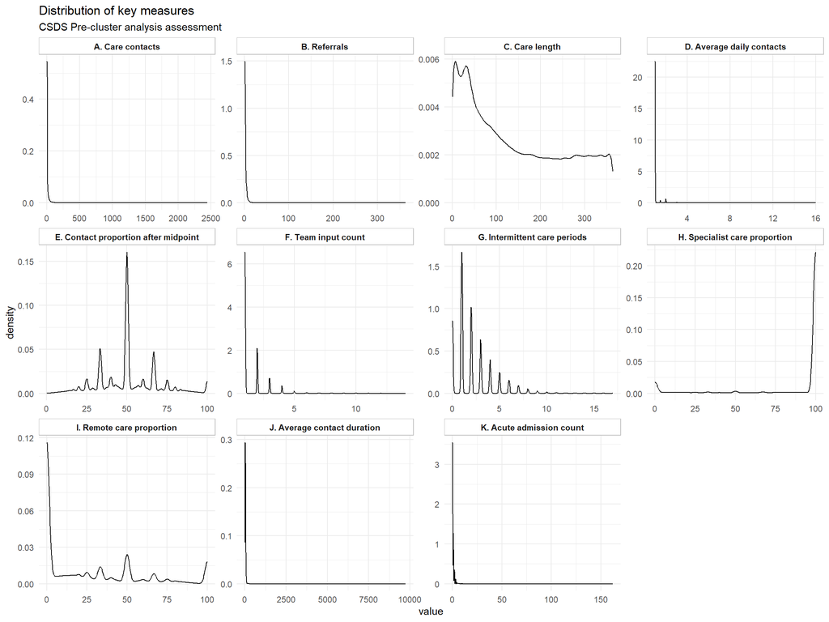

**Do I need to transform skewed variables?**

## 3. Outlier Detection

```r
remove_outliers <-
  key_measures_reduced_imp |>
  select(-org_id_provider) |>
  pivot_longer(cols = -person_id) |>
  group_by(name) |>
  mutate(quantile_99 = quantile(value, 0.99)) |>
  ungroup() |>
  filter(value > quantile_99) |>  # remove values above 99th percentile
  select(person_id) |>
  distinct()

key_measures_reduced_imp_ex_outlier <-
  key_measures_reduced_imp |>
  select(-org_id_provider) |>
  anti_join(remove_outliers, by = "person_id")
```

Plot distrubution with outliers removed:

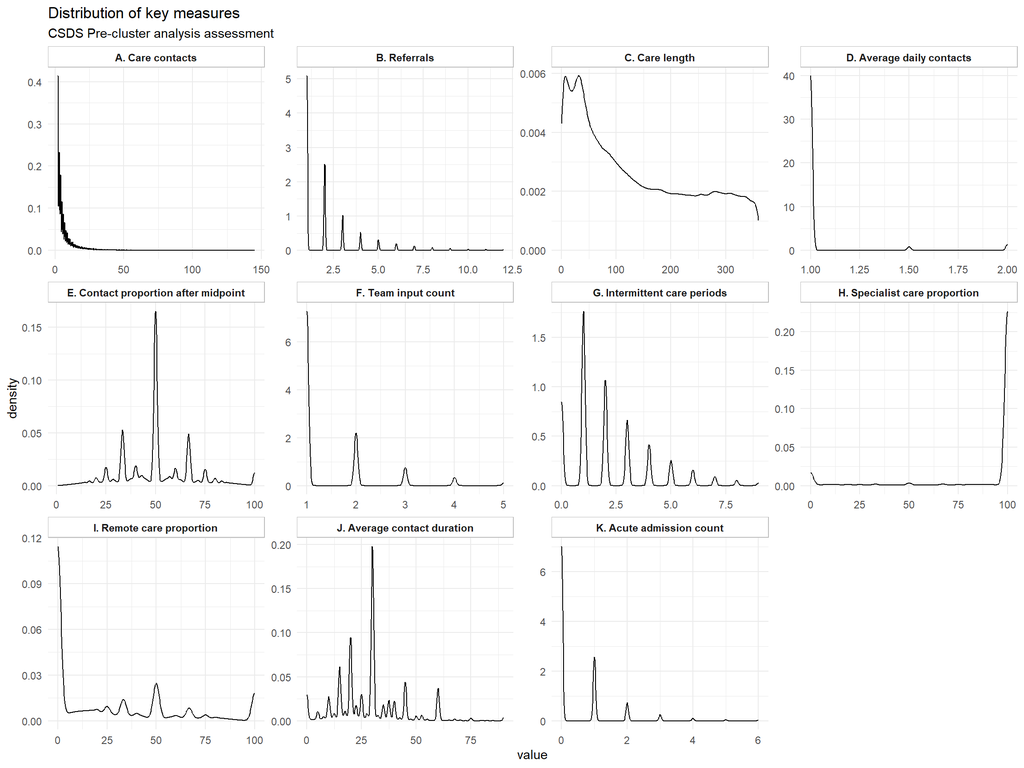

## 4. Correlation Analysis

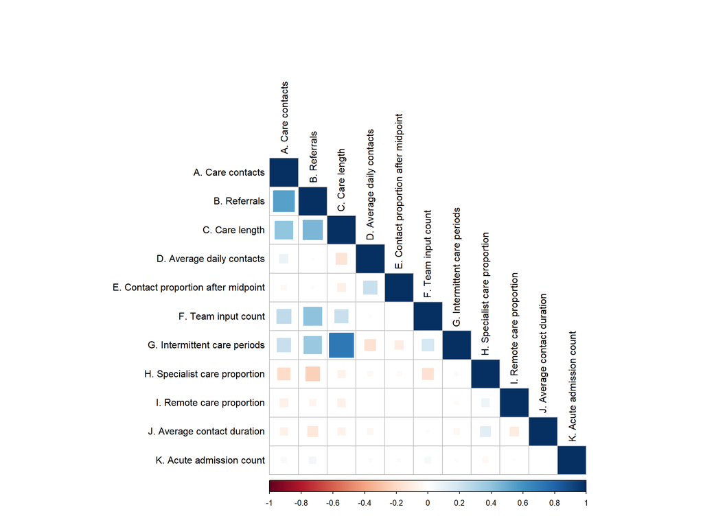

```r
cor_matrix_2 <-
  cor(
    key_measures_reduced_imp_ex_outlier |>
      pivot_longer(-person_id) |>
      left_join(key_measure_lookup, by = c("name" = "variable")) |>
      select(-name) |>
      pivot_wider(id_cols = "person_id",
                  names_from = "variable_clean",
                  values_from = "value") |>
      select(-person_id)
    )  # Exclude person_id

corrplot::corrplot(
  cor_matrix_2,
  method = "square",
  type = "lower",
  tl.col = "black"
)
```

## 5. Standardise/Normalise Data

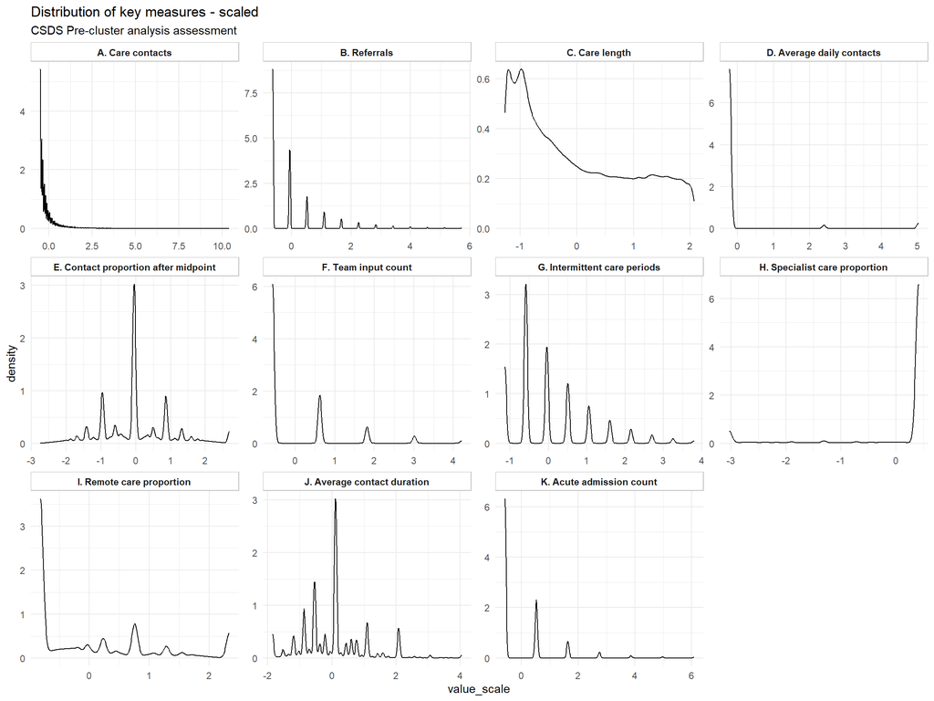

```r
key_measures_scaled <- scale(key_measures_reduced_imp_ex_outlier[, -1])  # Exclude person_id

key_measures_reduced_imp_ex_outlier |>
  pivot_longer(-person_id) |>
  group_by(name) |>
  mutate(value_scale = scale(value)) |>
  left_join(key_measure_lookup, by = c("name" = "variable")) |>

  ggplot(aes(x = value_scale)) +
  geom_density() +
  facet_wrap(~variable_clean, scales = "free") +
  theme_minimal() +
  theme(
    strip.background = element_rect(fill = NA, colour = "grey"),
    strip.text = element_text(face = "bold")
  ) +
  labs(title = "Distribution of key measures - scaled",
       subtitle = "CSDS Pre-cluster analysis assessment")
```

## 6. Assess Multicollinearity

```r
car::vif(lm(care_contacts ~ ., data = key_measures_reduced_imp_ex_outlier[, -1]))  # Example using VIF
```

```
                referrals               length_care    average_daily_contacts
                 1.534239                  2.280320                  1.082692
contact_prop_aft_midpoint          team_input_count intermittent_care_periods
                 1.055999                  1.215006                  2.118732
  specialist_contact_prop       remote_contact_prop      avg_contact_duration
                 1.100954                  1.029733                  1.047410
    acute_admissions_2223
                 1.005975
```

A Variance Inflation Factor (VIF) indicates the degree to which a predictor variable in a regression model is correlated with other predictor variables.

Interpretation:

- A value of **1 signifying no correlation** and higher values representing increasing levels of multicollinearity,
- A VIF **between 1 and 5** is considered **moderately correlated**,
- Values **above 5** suggest potentially problematic multicollinearity that might require **further investigation or corrective actions** like removing or combining highly correlated variables.

## 7. Dimensionality Reduction

Using PCA (Principal Component Analysis) to reduce dimensionality.

```r
pca_result <- prcomp(key_measures_scaled, center = TRUE, scale. = TRUE)
summary(pca_result)
```

```
Importance of components:
                          PC1    PC2    PC3     PC4     PC5    PC6     PC7
Standard deviation     1.6231 1.1909 1.0496 1.02402 1.00064 0.9572 0.91463
Proportion of Variance 0.2395 0.1289 0.1001 0.09533 0.09103 0.0833 0.07605
Cumulative Proportion  0.2395 0.3684 0.4686 0.56389 0.65492 0.7382 0.81427
                           PC8     PC9    PC10    PC11
Standard deviation     0.85248 0.80838 0.63705 0.50693
Proportion of Variance 0.06607 0.05941 0.03689 0.02336
Cumulative Proportion  0.88034 0.93974 0.97664 1.00000
```

Visualise the progressive proportion of variance explained by each variable:

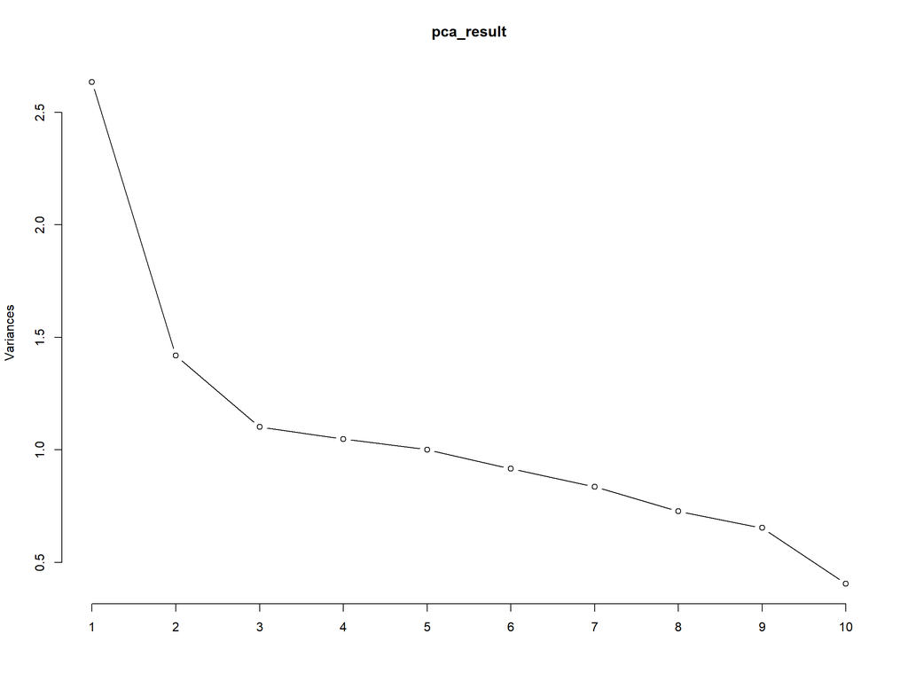

```r
screeplot(pca_result, type = "lines")
```

Additional visualisation:

```r
#biplot(pca_result)
```